Skip to release details

Cassy v3.67.0Release report · Published 20 October 2026 · 5:08 PM ET

# See delivery clearly, hear back sooner and keep work moving to the next person.

20 changes shipped across 7 areas; Tasks has the most, 8.

One dot, one shipped change. No GitHub issues are counted in this report's fixes ledger.

See every change ↓

## Release at a glance

01 / 06

**What shipped, by area**

One dot is one titled change group in the v3.67.0 CHANGELOG. Dots count changes, not their size or importance.

[output not shown]

Source: [published v3.67.0 CHANGELOG](https://github.com/Richards-LLC/cassy/blob/acfb0b0185e00f049426509d339217b954d1d610/CHANGELOG.md).

20Changes shipped

15 fixed, 5 changed; tests and docs not counted

Changes and GitHub issues are counted separately. A change is one top-level titled section in the v3.67.0 CHANGELOG; detailed items within each group appear under the hood but do not add dots. Tests and documentation entries are not counted. A GitHub issue counts when release PR #1322 or the CHANGELOG section references it and it closed between the PR opening (3:56 PM ET) and 15 minutes after its merge (5:07 PM ET). Issues are closed by hand shortly after the merge, so a report run inside that window waits for referenced issues that are still open. No GitHub issues are counted in this report's fixes ledger. Not measured for this release: green to published, request to published, cut to published, blockers, lesson recurrence, manual interventions.

## What you can do now

02 / 06

01

### Messages that get through

#### Did it arrive?

Wasa sent message could leave you guessing.

Nowsee RECEIVED when it reaches the recipient, or PENDING while Cassy keeps trying.

#### Honest delivery status

Wasa message that could not reach its reader could still look complete.

Nowsee it as undelivered with a reason, and keep its content for the next person handling the conversation.

#### Peer handoff

Wasa message for someone who signed out could stall or be called stale.

Nowit reaches the next available person or explains why it could not.

#### Faster follow-up

Wasan idle conversation could wait two minutes for another nudge.

NowCassy checks after 30 seconds and tries again each minute.

#### Earlier alerts

Wasan unread message could wait two hours before an alert.

Nowthe default alert tells you and the people responsible for your workspace after five minutes.

#### The right conversation

Wasa message could be picked up by a different conversation.

Nowit stays with the person it was meant for.

#### The next instruction

Wasan older closed request could hide a new assignment.

Noweach request stays clear, and an expired assignment gets an explanation.

#### Brief Slack outages

Wasa short connection loss could be handled differently by different Cassy actions.

NowCassy tries to reconnect briefly and gives the same clear answer if it cannot.

02

### Safer cleanup and recovery

#### Keep another project's work

Wascleanup could miss a matching owner.

Nowit checks every relevant project and stops when ownership is uncertain.

#### Preview before signing in

Wasseeing which saved changes could move to your team required a login.

Nowpreview locally without signing in; log in only to apply it.

#### A clearer next step

Wassaved updates waiting for a fix could hide a second problem or suggest a useless retry.

Nowsee accurate counts, both findings and the right remedy.

#### Shared contact limits

WasCassy could miss a contact limit stored on another device.

Nowit checks that shared limit before sending and tells you when it cannot reach the other device.

#### Keep the whole note

Wasone invisible character could block a note's sync, and a workaround would delete it.

Nowthe text stays unchanged and the note stays safely queued.

03

### Replies and setup

#### Files in Slack replies

Wasadding a file to an existing Slack reply needed manual setup.

Nowinclude the file when you send the reply.

#### Delivery handoff reports

Wascompletion reports required manually assembling requirements and feedback rounds.

Nowa guided report tracks both in one branded handoff.

#### Quieter reminders

Wasprompts could repeat after action was taken or while a review was still underway.

Nowonly reminders that still need action are sent.

#### Quicker Codex checks

Waschecking an installed version could add another wait.

NowCassy checks only when needed within its existing setup timeout.

#### Reliable updates

Wasan update could leave Cassy's hub on an older version or say it had stopped while it was still starting.

NowCassy gives a repair step and shows `starting` until ready.

#### Branded release reports

Wasrelease reports looked different from the rest of Cassy.

Nowthe report and printout share Cassy's colors, lettering and logo, with clean page breaks.

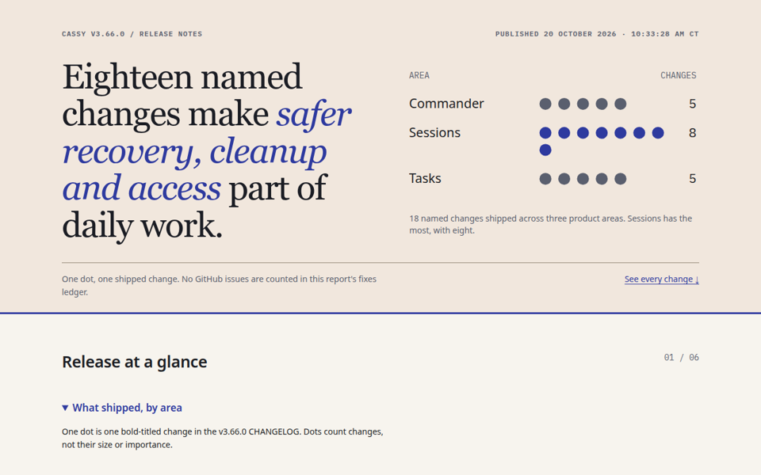

Before

[figure not shown]

After

Source: [CHANGELOG at the published commit](https://github.com/Richards-LLC/cassy/blob/acfb0b0185e00f049426509d339217b954d1d610/CHANGELOG.md).

## Under the hood

03 / 06

01

### Acknowledged delivery

#### Receipt verdict

Wasa pane handoff looked like completion.

Now`message_status` leads with RECEIVED or PENDING from recipient evidence, and names ended deliveries without a receipt.

#### Abandoned messages

Wasan item could still report Delivered after wake checks were declined; the sender saw no cause and a successor lacked the message.

Nowit reports Undelivered, names the reason and carries content to the next live session.

#### Idle wake cadence

Wasthe normal watchdog waited 120 seconds and retried once.

Nowit checks after 30 seconds, then nudges every 60 seconds up to five times while no turn has started.

#### Wake bursts

Wasseveral messages could repeat wake work, and an optional batch failure could interrupt delivery.

Nowdirected wakes are debounced, share bounded deadlines and still deliver when batching fails.

#### Escalation

Wasunread messages could wait hours before escalation.

Nowpriority and normal thresholds both default to 300 seconds, notifying the sender and operator.

#### Caller identity

Wasresponse fallback could drain a parent's mail for a child call.

Nowcaller identity is checked before mail is surfaced or consumed.

#### Correct message context

Wasa message mentioning older work could be treated as a stale delivery.

Nowit is tied to the intended context, and a truly closed target gets an explicit refusal.

#### Violet reconnects

Wascommand-line and background delivery classified proxy outages differently.

Nowboth use the shared MCP reconnect mapping and bounded retry policy.

#### Peer succession

Wasmessages for an ended or signed-out recipient could stall or look stale.

Nowthey reach a verified successor when available, or return a clear refusal with bounded recovery details.

02

### Cloud and command safety

#### Cleanup ownership

Wasglobal task ownership and concurrent checkpoints could go unverified.

Nowproject and global stores are checked read-only, with bounded retries and uncertain ownership refused.

#### Credential path resolution

Wasa command could reach saved credentials with relative paths after changing directories.

Nowdirectory changes and recursive path operands are checked before access.

#### Local queue preview

Wasa dry-run migration could trigger Cloud credential preflight.

Nowthe read-only plan loads no credentials; applying it still requires authentication.

#### Queue diagnostics

Washeld personal rows counted even when they could not migrate, and generic retry advice obscured the cause.

Nowcounts cover migratable rows and held-only queues point to the migration remedy.

#### Stable migration plans

Wasduplicate personal rows could make preview differ from apply.

Nowboth use one deduplicated eligibility plan without discarding original rows.

#### Transient sync recovery

Wasa temporary network failure could leave personal sync work parked.

Nowbounded retries re-arm it without duplicating the queued work.

#### Lossless task notes

WasNUL rejection advice blocked recovery and an interim repair stripped text.

Nowstored notes and queued payloads stay exact; rows remain parked until Cloud can round-trip NUL losslessly.

03

### Replies and review flow

#### Managed-thread files

Wasa local-file reply lacked automatic reply-intent fields and could be refused as external.

Nowthe caller's intent supplies thread and claim checks for a normal file reply, with the same request id for a safe retry.

#### Replaced drafts

Wasa newer message from the same task could be reported as a dropped delivery after a sync changed its draft.

Nowits own replacement is recognized as a superseding update.

#### Actionable notifications

Wasalready handled events or activity that still needed a review could trigger another prompt.

Nownotices follow current state and appear only when they still need action.

#### Cross-project proposals

Wasaliases could make an accepted task's target mismatch or leave ownership dependent on notes.

Nowregistered project identity is resolved consistently and a local acceptance record grounds the receipt.

#### Accepted proposal history

Wasaccepted work could disappear from its board or be pruned from untrusted notes.

Nowit stays visible and its acceptance record controls retention.

#### Delivery accounting

Wasshared or reassigned branches could make completed deliveries look stranded.

Nowclose checks each delivery's own branch, including earlier owners' remaining commits.

#### Named task handoff

Wasa caller-supplied assignment tag or a busy session could start the wrong task.

Nowuntrusted tags are discarded and each start binds to its named task.

#### Planning scope

Wasa plan could hide overlapping work or a local outage, or include work outside a peer's scope.

Nowwarnings remain visible and plans stay within the requested scope.

#### Lifecycle-safe rework

Wasan older sync event could reopen work after a newer delivery decision.

Nowrework follows the latest task lifecycle action.

#### Merge alert completion

Wasa terminal fallback or delayed native alert could lose an unfinished merge notice.

Nowalert work is rechecked against the current inbox and completion is retained through fallback.

#### Generated skill history

Wasa close check could run an unsupported generator or compare stale generated references.

Nowit uses the supported scoped generator and rebuilds each output from merged history.

#### Task delivery range

Wastarget-branch syncs could make a task's own delivery look like extra work.

Nowdelivery checks skip target-sync merges and follow that task's branch tip.

#### Shared contact authority

Wasnamed-contact posts could proceed without a shared contact check, or leave the outcome unclear on timeout.

Nowauthority is reserved before sending, retries keep one request identity and local uncertainty is visible.

04

### Proof, splits and setup

#### Portable proof

Wasevidence and its task context could stay on one machine or branch.

Nowsynced notes carry proof artifacts, and parked reviews recover only for the owning machine and session.

#### ARTIFACT_PROOF field refusals

Wasselected evidence fields could accept caller-supplied markers.

Nowclose/cancel/reopen/request_changes/QA reasons, transfer notes, stranded override, spawn_brief and worktree_merge reason refuse them.

#### Fair work splits

Wasa split needed both sides to request or grant at once, and expired claims could strand child work.

Noweither side can initiate, decisions are recorded, old children are retired before reuse, and a live successor can cancel an expired orphan after verifying its owner is gone.

#### Parked checkout adoption

Wasa receiving session could lose commits from a parked source checkout.

Nowadoption preserves its history and reconciles the linked checkout before work resumes.

#### Viktor opt-out

Wasa saved opt-out could be ignored by later prompts, and an explicit re-add could remain disabled.

Nowopt-out persists and an explicit add enables Viktor again.

05

### Developer and release tooling

#### Elegant tests

Wastest-first required a new file, and one verifier verdict could create a project rule.

Nowa changed test case in an existing file qualifies, while reusable lessons stay candidates until separate tasks repeat them.

#### Release reports

Wasempty issue captions could count outside the report ledger, and a closing folio could create a footer-only page.

Nowcounts stay scoped to that ledger and the final page keeps its content.

#### Commander-branded reports

Wasreport pages did not follow the Cassy hub's visual system.

Nowshared colors, type, mark, Was→Now cards and example captures carry through HTML and print.

#### Installed hub binary

Wasupdate could restart a stale launchd or systemd executable, with no repair guidance.

Nowit checks the service definition before restart and points to `cas hub service install` when they differ.

#### Startup readiness

Wasservice install reported not running just after activation.

Nowit reports `starting` until the runtime is ready.

#### Hub status phases

Wasstatus could lose the startup phase or give drift advice outside the affected service.

Nowit retains the phase and scopes repair guidance to the detected drift.

#### Codex version probe

Wassuffixes and abbreviated versions confused model-cache checks.

Nowversions compare consistently, and an on-demand probe fits the existing five-second account deadline.

#### Linux isolation design

Waschanging HOME alone left absolute credential paths visible.

Nowthe Linux prototype recommends a mount boundary and explicit tool/auth grants; production enforcement and macOS support remain pending.

#### SOW delivery reports

Wascompleting client work relied on manually assembling requirements, feedback rounds and screenshots.

Nowa built-in workflow checks each outcome, tracks feedback, pairs requested changes with real captures and prepares a branded report and PM handoff.

#### SOW report hygiene

Wasambiguous client terms or a sign-in redirect could pass as report evidence.

Nowclient identifiers and standards are bounded, and login success is checked before capture.

#### Viktor import cleanup

Wascase and import variants could create duplicate or mismatched accounts.

Nowidentities are normalized before cleanup.

#### Actionable login check

Wasa login preflight could overflow a narrow terminal.

Nowits explanation wraps and keeps the next action visible.

#### Readable SOW captures

Wasreport evidence could be cramped on phones or lose full-width print flow.

Nowclient identifiers are preserved and captures fit phone and print layouts.

## Fixes ledger

04 / 06

GitHub issues closed with this release · 0

| Issue | Title | Closed | Area |
| --- | --- | --- | --- |

No GitHub issues are counted in this report's fixes ledger.

## Install

05 / 06

```
cas update --yes --version 3.67.0
```

- [macOS ARM64 archive](https://github.com/Richards-LLC/cassy/releases/download/v3.67.0/cas-aarch64-apple-darwin.tar.gz) — `cas-aarch64-apple-darwin.tar.gz` · SHA-256 `a08d0bb25b88c191dda22bd359e33ce8be18d7231912d3057dfb209f17dfe57d` · 33,574,588 bytes.
- [Linux x86_64 archive](https://github.com/Richards-LLC/cassy/releases/download/v3.67.0/cas-x86_64-unknown-linux-gnu.tar.gz) — `cas-x86_64-unknown-linux-gnu.tar.gz` · SHA-256 `8e6aaed97d40f87641460d692d65ae24b62ff847f01153f4922b19f30f894c66` · 38,818,822 bytes.

## Evidence and scope

06 / 06

Retrieved 20 October 2026 · 5:17 PM ET from the [published CHANGELOG](https://github.com/Richards-LLC/cassy/blob/acfb0b0185e00f049426509d339217b954d1d610/CHANGELOG.md), [release-notes draft](https://github.com/Richards-LLC/cassy/blob/acfb0b0185e00f049426509d339217b954d1d610/docs/release-notes/2026-10-20-v3.67.0-slack.md), [release PR #1322](https://github.com/Richards-LLC/cassy/pull/1322) and [published release v3.67.0](https://github.com/Richards-LLC/cassy/releases/tag/v3.67.0).

The map groups each CHANGELOG section by its title and body. The issue window is the release PR opening at 3:56 PM ET through 15 minutes after its 4:52 PM ET merge (5:07 PM ET); no issues named by the PR or CHANGELOG closed in that window. The release was published at 5:08 PM ET.

Green-to-published, request-to-published, cut-to-published and stage timings are unavailable because no latency receipt was recorded. No tag timing is used as a substitute.